# Plotting Systems in R

David Asare Kumi

June 7, 2019

We have three plotting systems in R

- Base Plotting System
- ggplot2
- Lattice

## The Base Plotting System

- “Artist’s pellete” model
- Start with blank canvas, and build up from there
- Start with plot function (or similar)
- Use annotation functions to add/modify (text,lines,points,axis)

### Key notes

- The base plotting system is the oldest plotting system
- There are functions that generate the plots and other functions annotate the plots

### Advantages

- Convenient.
- Mirrors how we think of building plots and analyzing data.

### Drawbacks

- Cannot go back once plot has started (i.e. to adjust margins);need to plan in advance.
- Difficult to translate to others once a new plot has been created (no graphical language).
- Plot is just a series of R commands.

## Base Plot

```r
#Plot a scatterplot
library(datasets)
data(cars)
dim(cars)
```

```
## [1] 50  2
```

```r
names(cars)
```

```
## [1] "speed" "dist"
```

```r
summary(cars)
```

```
##      speed           dist
##  Min.   : 4.0   Min.   :  2.00
##  1st Qu.:12.0   1st Qu.: 26.00
##  Median :15.0   Median : 36.00
##  Mean   :15.4   Mean   : 42.98
##  3rd Qu.:19.0   3rd Qu.: 56.00
##  Max.   :25.0   Max.   :120.00
```

```r
str(cars)
```

```
## 'data.frame':    50 obs. of  2 variables:
##  $ speed: num  4 4 7 7 8 9 10 10 10 11 ...
##  $ dist : num  2 10 4 22 16 10 18 26 34 17 ...
```

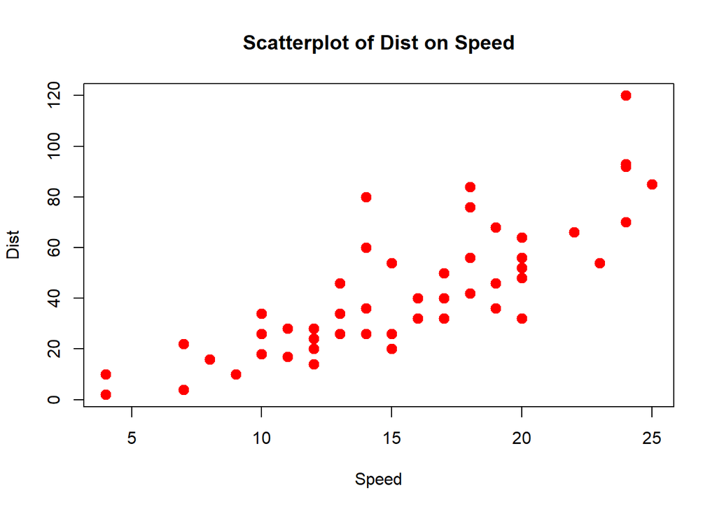

```r
with(cars,plot(speed,dist,cex=2,pch=20,col="red",xlab="Speed",ylab="Dist",
               main="Scatterplot of Dist on Speed"))
```

```r
#Plot multiple boxplots
data(InsectSprays)
names(InsectSprays)
```

```
## [1] "count" "spray"
```

```r
dim(InsectSprays)
```

```
## [1] 72  2
```

```r
str(InsectSprays)
```

```
## 'data.frame':    72 obs. of  2 variables:
##  $ count: num  10 7 20 14 14 12 10 23 17 20 ...
##  $ spray: Factor w/ 6 levels "A","B","C","D",..: 1 1 1 1 1 1 1 1 1 1 ...
```

```r
table(InsectSprays$spray)
```

```
##
##  A  B  C  D  E  F
## 12 12 12 12 12 12
```

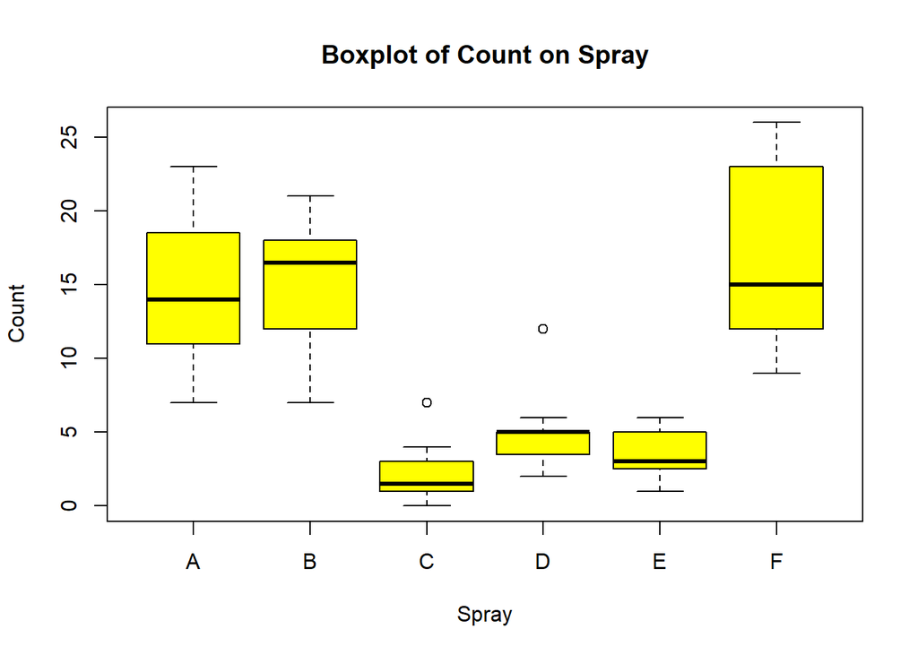

```r
boxplot(count~spray,data=InsectSprays,col="yellow",xlab="Spray",ylab="Count",
        main="Boxplot of Count on Spray")
```

## The Lattice Plotting System

This is implemented in the lattice package

- Plots are created with a single function call (xyplot,bwplot,etc).
- Most useful for conditioning types of plots: Looking at how y changes with x across levels of z.
- Things like margins,spacing are set automatically because entire plot is specified at once.
- Good for putting many plots on a screen.

### Key notes

- Here you have to specify a lot of information.
- Lattice plots are panel plots.

### Downside/Drawbacks

- Sometimes awkward to specify an entire plot in a single function call.
- Annotation in plot is not especially intuitive.
- Use of panel functions and subscripts difficult to wield(use,employ) and requires intense preparation.
- Cannot add to plot once it is created.

## Lattice Plot

```r
library(lattice)
data(USMortality)
dim(USMortality)
```

```
## [1] 40  5
```

```r
names(USMortality)
```

```
## [1] "Status" "Sex"    "Cause"  "Rate"   "SE"
```

```r
summary(USMortality)
```

```
##    Status       Sex                          Cause         Rate
##  Rural:20   Female:20   Alzheimers              : 4   Min.   :  5.30
##  Urban:20   Male  :20   Cancer                  : 4   1st Qu.: 18.98
##                         Cerebrovascular diseases: 4   Median : 30.05
##                         Diabetes                : 4   Mean   : 58.73
##                         Flu and pneumonia       : 4   3rd Qu.: 52.90
##                         Heart disease           : 4   Max.   :242.70
##                         (Other)                 :16
##        SE
##  Min.   :0.00
##  1st Qu.:0.10
##  Median :0.20
##  Mean   :0.18
##  3rd Qu.:0.20
##  Max.   :0.60
##
```

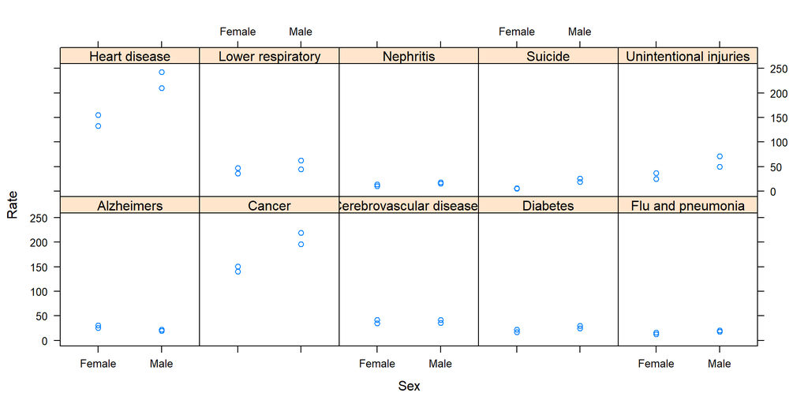

```r
xyplot(Rate~Sex|Cause,data=USMortality,layout=c(5,2))
```

## ggplot2 System

This comes from a grammar of graphics (language for plotting)

- Splits the difference between base and lattice in a number of ways.
- Automatically deals with spacings, text, titles, but allows you to annotate by “adding” to a plot.
- Superficial similarity to lattice but generally easier and more intuitive to use.
- Default mode makes many choices for you (but you can still customize to your heart’s desire).
- This is implemented in R in the ggplot2 package.
- The ggplot2 is also useful for conditioning plots.

## ggplot2 Plot

```r
library(ggplot2)
library(dplyr)
data(mpg)
dim(mpg)
```

```
## [1] 234  11
```

```r
names(mpg)
```

```
##  [1] "manufacturer" "model"        "displ"        "year"
##  [5] "cyl"          "trans"        "drv"          "cty"
##  [9] "hwy"          "fl"           "class"
```

```r
glimpse(mpg)
```

```
## Observations: 234
## Variables: 11
## $ manufacturer <chr> "audi", "audi", "audi", "audi", "audi", "audi", "...
## $ model        <chr> "a4", "a4", "a4", "a4", "a4", "a4", "a4", "a4 qua...
## $ displ        <dbl> 1.8, 1.8, 2.0, 2.0, 2.8, 2.8, 3.1, 1.8, 1.8, 2.0,...
## $ year         <int> 1999, 1999, 2008, 2008, 1999, 1999, 2008, 1999, 1...
## $ cyl          <int> 4, 4, 4, 4, 6, 6, 6, 4, 4, 4, 4, 6, 6, 6, 6, 6, 6...
## $ trans        <chr> "auto(l5)", "manual(m5)", "manual(m6)", "auto(av)...
## $ drv          <chr> "f", "f", "f", "f", "f", "f", "f", "4", "4", "4",...
## $ cty          <int> 18, 21, 20, 21, 16, 18, 18, 18, 16, 20, 19, 15, 1...
## $ hwy          <int> 29, 29, 31, 30, 26, 26, 27, 26, 25, 28, 27, 25, 2...
## $ fl           <chr> "p", "p", "p", "p", "p", "p", "p", "p", "p", "p",...
## $ class        <chr> "compact", "compact", "compact", "compact", "comp...
```

```r
table(mpg$manufacturer)
```

```
##
##       audi  chevrolet      dodge       ford      honda    hyundai
##         18         19         37         25          9         14
##       jeep land rover    lincoln    mercury     nissan    pontiac
##          8          4          3          4         13          5
##     subaru     toyota volkswagen
##         14         34         27
```

```r
table(mpg$model)
```

```
##
##            4runner 4wd                     a4             a4 quattro
##                      6                      7                      8
##             a6 quattro                 altima     c1500 suburban 2wd
##                      3                      6                      5
##                  camry           camry solara            caravan 2wd
##                      7                      7                     11
##                  civic                corolla               corvette
##                      9                      5                      5
##      dakota pickup 4wd            durango 4wd         expedition 2wd
##                      9                      7                      3
##           explorer 4wd        f150 pickup 4wd           forester awd
##                      6                      7                      6
##     grand cherokee 4wd             grand prix                    gti
##                      8                      5                      5
##            impreza awd                  jetta        k1500 tahoe 4wd
##                      8                      9                      4
## land cruiser wagon 4wd                 malibu                 maxima
##                      2                      5                      3
##        mountaineer 4wd                mustang          navigator 2wd
##                      4                      9                      3
##             new beetle                 passat         pathfinder 4wd
##                      6                      7                      4
##    ram 1500 pickup 4wd            range rover                 sonata
##                     10                      4                      7
##                tiburon      toyota tacoma 4wd
##                      7                      7
```

```r
table(mpg$cyl)
```

```
##
##  4  5  6  8
## 81  4 79 70
```

```r
table(mpg$fl)
```

```
##
##   c   d   e   p   r
##   1   5   8  52 168
```

```r
table(mpg$year)
```

```
##
## 1999 2008
##  117  117
```

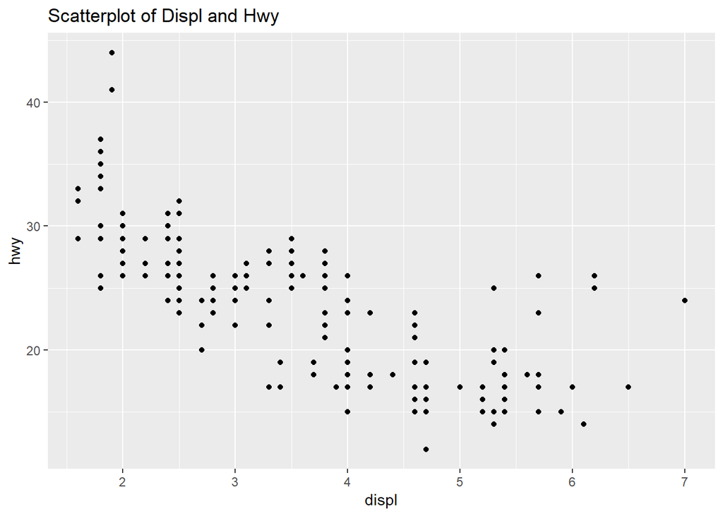

```r
#Plot graphs
qplot(displ,hwy,data=mpg,main="Scatterplot of Displ and Hwy")
```

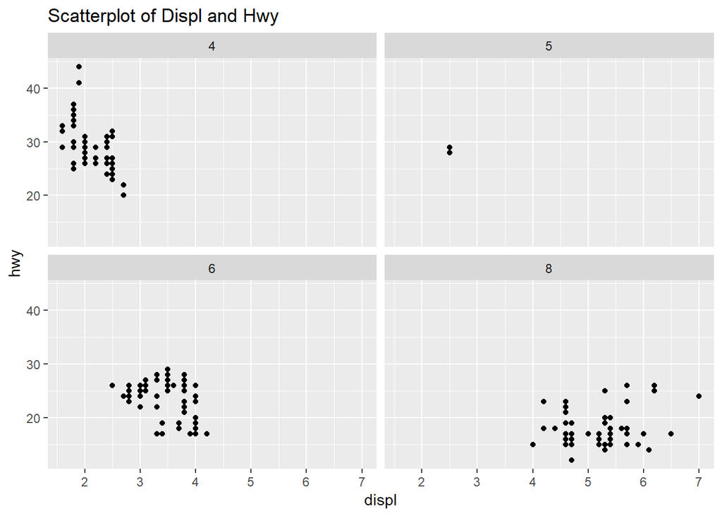

```r
qplot(displ,hwy,data=mpg,main="Scatterplot of Displ and Hwy",facets=~cyl)
```

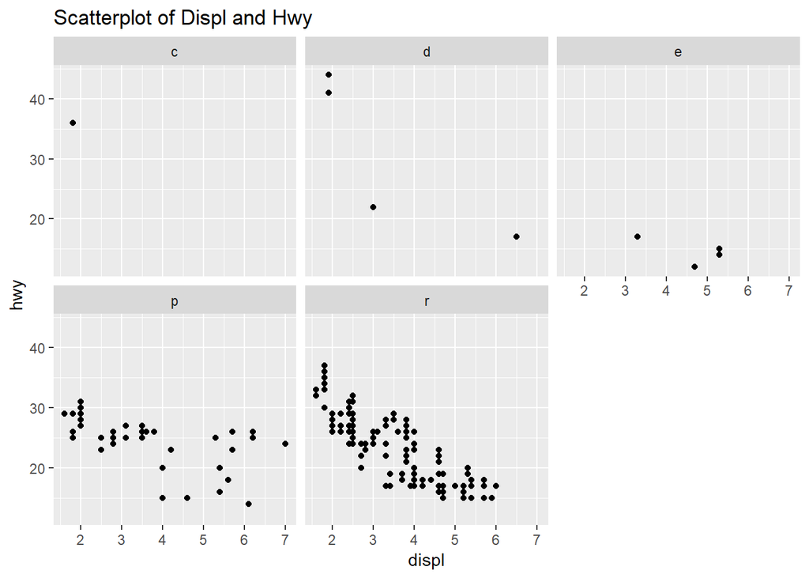

```r
qplot(displ,hwy,data=mpg,main="Scatterplot of Displ and Hwy",facets=~fl)
```